## ENFOQUE MULTINIVEL

Al tratarse de datos de panel, en los que hay individuos que participan en varias oleadas, no podemos considerar las observaciones como independientes. Más aún, podríamos considerar a los individuos como factor aleatorio anidado dentro de las cohortes, y así recogemos esa estructura de correlación.

Es decir, asumimos que la participación presenta correlación entre individuos de la misma cohorte y también dentro de la respuesta de cada individuo en las diferentes olas.

### Un poco de teoría

#### Modelo regresión logística clásico

$P[y_{i}=1]= \text{logit}^{-1} (\mathbf{X}_i\beta)$

Notamos $P[y_{i}=1]$ a la probabilidad de que un individuo i tenga como valor “partic” en la variable participación

Dónde las variable $cohorte_i$ vale 1 si la observación pertenece a la cohorte i y 0 en otro caso.

#### Modelo mixto

Supongamos un modelo mixto con un sólo factor aleatorio, por ejemplo para la variable cohorte

$P[y_{i}=1]= \text{logit}^{-1} (\alpha_0+\alpha^{cohorte}_{j[i]})$

$\alpha^{cohorte}_j \backsim\mathcal{N}(0,\sigma^2_{cohorte})$

El modelo estima varianzas, pero una vez estimada se pueden realizar predicciones para las medias en cada grupo, realizando una estimación ponderada. Es lo que se llama un BLUP (Best Linear Unbiased Prediction). Por ejemplo para la cohorte 1.

$\widehat{\alpha}^{multinivel}_{cohorte 1}\approx\dfrac{\frac{n_{cohorte 1}}{\sigma^2_y}\bar{y}_{cohorte 1}+\frac{1}{\sigma^2_{cohorte 1}}\bar{y}_{total}}{\frac{n_{cohorte 1}}{\sigma^2_y}+\frac{1}{\sigma^2_{cohorte}}}$

Dónde $\widehat{\alpha}^{multinivel}_{cohorte 1}$ se corresponde con la modificación que la cohorte 1 añade a la estimación de la constante ($\alpha_0$) en el modelo de regresión logística mixto.

Esta forma de obtener las medias en cada cohorte (más bien proporciones de participación en cada cohorte) suele ser mejor que la que da el modelo de regresión logística clásico, ya que en este caso para estimar la *media* en una cohorte se tiene en cuenta la información de la distribución en el global de cohortes. Este método es uno de los usados en estimaciones en áreas pequeñas, y es muy útil cuando se tienen categorías con poco tamaño muestral. Para las categorías con menor muestra BLUP se parece más a la *media global* mientras que para categorías con mayor muestra BLUP se aproxima más a la *media de la categoría* . Esta forma de predecir las medias en cada categoría nunca va a funcionar peor que la obtenida por regresión logística clásica y este tipo de modelos son más parsimoniosos e incluyen la ventaja de poder añadir covariables a varios niveles.

El estimador BLUP es más complejo conforme añadimos factores fijos y aleatorios al modelo, pero en general sigue siendo una estimación ponderada en la que se tiene en cuenta el tamaño muestral de la categoría, su media observada, la media global y la varianza estimada por el modelo.

En datos de panel, no se cumple la asunción de que las observaciones sean i.i.d (independientes e idénticamente distribuidas) y por tanto no es correcto utilizar modelos lineales clásicos (o lineales generalizados como la reg logística). Los modelos mixtos se adaptan a la perfección a este tipo de datos puesto que permiten modelar estructuras de correlación complejas. En nuestro caso, nos permite modelar la correlación entre observaciones del mismo individuo y anidado dentro de cohorte.

### Cálculos

Vamos a comprobar en primer lugar que incluir el efecto aleatorio de individuos anidados dentro de cohortes es mejor que el modelo que sólo tiene la media global.

```r
fit1 <- glm(participacion ~ 1, family=binomial, data=share.clean.paises.3.olas)
```

Modelo mixto considerando los individuos anidados dentro de las cohortes.

```r
fit.glmer.1 <- glmer( participacion ~  (1 | dn003_cat/mergeid) ,
                                    nAGQ=0,
                                        family=binomial, data=share.clean.paises.3.olas)
```

No hay forma de comparar ambos modelos mediante un test, pero podemos ver su valor del AIC (Akaike Information Criterium) el cual penaliza los modelos con mayor número de parámetros

```r
AIC(fit1, fit.glmer.1)
```

```
##             df    AIC
## fit1         1 108800
## fit.glmer.1  3 103195
```

Y consideramos como mejor el modelo el que tenga menor AIC

### Comparación entre las estimaciones de un modelo multinivel y uno clásico

Vamos a representar gráficamente las estimaciones de los porcentajes de participación en cada cohorte por dos modelos.

- Modelo logístico multinivel (o mixto) dónde se consideran como factores aleatorios los individuos anidados dentro de cohortes.
- Modelo logístico clásico con la variable cohorte como predictor categórico.

En el modelo logístico multinivel se pueden predecir las proporciones medias mediante el estimador BLUP, mientras que en el logístico clásico se utiliza la estimación usual, (estimador BLUE).

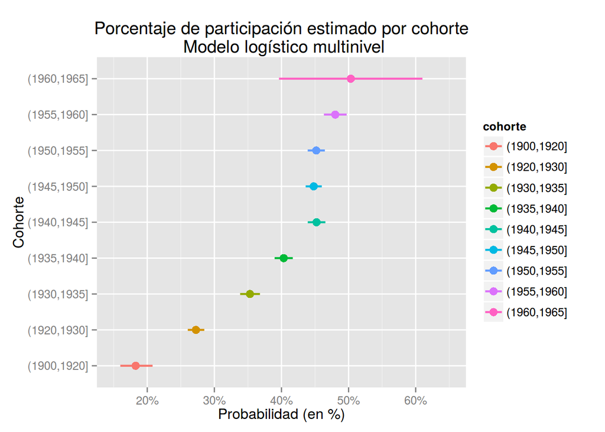

También podemos comparar con un modelo de regresión logística equivalente. No pongo los mergeid (individuos) como factor fijo porque sería un modelo con más de 30.000 parámetros

```r
fit2 <- glm(participacion ~ dn003_cat ,family = binomial,
                        data = share.clean.paises.3.olas )
```

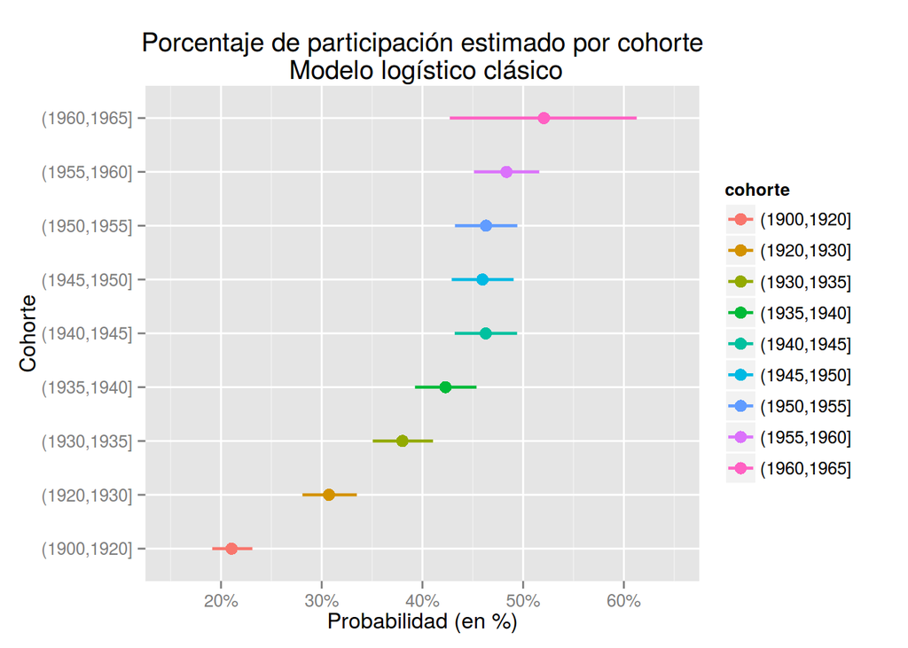

Además en general, el modelo multinivel es más preciso (menor varianza) y tiene menor sesgo (ver por ejemplo el artículo “How Should We Estimate Public Opinion in The States?” de Jeffrey R. Lax y Justin H. Phillips en American Journal of Political Science, Vol. 53, No. 1, January 2009, Pp. 107–121). Yo he realizado simulaciones utilizando la EPA dónde los modelos logísticos multinivel demuestran mejores propiedades en términos de sesgo y precisión que los tradicionales)